# breast_cancer

## El cáncer de mama

Como introduccion, hablemos por encima sobre el **cáncer de mama**.

El cáncer de mama es el crecimiento descontrolado de las **células mamarias** originándose generalmente en las células de los lobulillos. Esto es el resultado de **mutaciones** en los genes que regulan el crecimiento de las células y las mantienen sanas.

Normalmente, las células del cuerpo se renuevan mediante un proceso específico llamado crecimiento celular: las células nuevas y sanas ocupan el lugar de las células viejas que mueren. Pero con el paso del tiempo, las mutaciones romper el equilibrio y pueden hacer que una célula se divida sin ningun tipo de control, generando un **tumor**.

Los tumores se consideran **malignos** (cancerosos) si invaden otros tejidos y se propagan a otras partes del cuerpo o **benignos** en caso contrario.

## Datos

La base de datos esta formada por 569 instancias de las caules 357 tienen la etiqueta *beningn* y 212 *malignant* . Además cada instancia contiene 33 columnas.

La base de datos puede encontrarse en la pagína oficial UCI Machine Learning Repository, en el siguiente enlace: https://archive.ics.uci.edu/ml/datasets/Breast+Cancer+Wisconsin+%28Diagnostic%29

```python
import numpy as np
import pandas as pd
import os
import matplotlib as mpl
import matplotlib.pyplot as plt
import seaborn as sns
from sklearn.model_selection import train_test_split, RandomizedSearchCV, GridSearchCV
sns.set_style('darkgrid')
%matplotlib inline
```

```python
data=pd.read_csv('datasets/breast cancer/data.csv')
```

Echamos un primer vistazo al *dataframe* que tenemos, para ver la estructura del mismo. Posteriormente separamos por un lado los datos y por otro las etiquetas. Además descartamos de entrada las columnas que no nos ofrecen ningún valor.

```python
data.head()
```

|  | id | diagnosis | radius_mean | texture_mean | perimeter_mean | area_mean | smoothness_mean | compactness_mean | concavity_mean | concave points_mean | ... | texture_worst | perimeter_worst | area_worst | smoothness_worst | compactness_worst | concavity_worst | concave points_worst | symmetry_worst | fractal_dimension_worst | Unnamed: 32 |
| --- | --- | --- | --- | --- | --- | --- | --- | --- | --- | --- | --- | --- | --- | --- | --- | --- | --- | --- | --- | --- | --- |
| 0 | 842302 | M | 17.99 | 10.38 | 122.80 | 1001.0 | 0.11840 | 0.27760 | 0.3001 | 0.14710 | ... | 17.33 | 184.60 | 2019.0 | 0.1622 | 0.6656 | 0.7119 | 0.2654 | 0.4601 | 0.11890 | NaN |
| 1 | 842517 | M | 20.57 | 17.77 | 132.90 | 1326.0 | 0.08474 | 0.07864 | 0.0869 | 0.07017 | ... | 23.41 | 158.80 | 1956.0 | 0.1238 | 0.1866 | 0.2416 | 0.1860 | 0.2750 | 0.08902 | NaN |
| 2 | 84300903 | M | 19.69 | 21.25 | 130.00 | 1203.0 | 0.10960 | 0.15990 | 0.1974 | 0.12790 | ... | 25.53 | 152.50 | 1709.0 | 0.1444 | 0.4245 | 0.4504 | 0.2430 | 0.3613 | 0.08758 | NaN |
| 3 | 84348301 | M | 11.42 | 20.38 | 77.58 | 386.1 | 0.14250 | 0.28390 | 0.2414 | 0.10520 | ... | 26.50 | 98.87 | 567.7 | 0.2098 | 0.8663 | 0.6869 | 0.2575 | 0.6638 | 0.17300 | NaN |
| 4 | 84358402 | M | 20.29 | 14.34 | 135.10 | 1297.0 | 0.10030 | 0.13280 | 0.1980 | 0.10430 | ... | 16.67 | 152.20 | 1575.0 | 0.1374 | 0.2050 | 0.4000 | 0.1625 | 0.2364 | 0.07678 | NaN |

5 rows × 33 columns

```python
data['Unnamed: 32']
```

```
0     NaN
1     NaN
2     NaN
3     NaN
4     NaN
       ..
564   NaN
565   NaN
566   NaN
567   NaN
568   NaN
Name: Unnamed: 32, Length: 569, dtype: float64
```

```python
target=pd.Series(data['diagnosis'], name='diagnosis')
data.drop(columns=['diagnosis', 'id', 'Unnamed: 32'], inplace=True) #dropping unnecesary columns
```

```python
print(f'Number of Benigns: {target.value_counts()[0]}')
print(f'Number of Malignants: {target.value_counts()[1]}')
```

```
Number of Benigns: 357
Number of Malignants: 212
```

Antes de seguir explorando los datos, vamos a separar nuestro set de entrenamiento y nuestro set de testeo.

```python
X_train, X_test, y_train, y_test=train_test_split(data, target, test_size=0.3, random_state=42)
```

Vemos las diferencias de escala que existen entre las columnas. Para hacer mucho más intuitivos los posteriores grafos y para mejorar el rendimiento de algunos de los clasificadores que vamos a emplear más adelante, estandarizamos los datos.

```python
X_train.describe()
```

|  | radius_mean | texture_mean | perimeter_mean | area_mean | smoothness_mean | compactness_mean | concavity_mean | concave points_mean | symmetry_mean | fractal_dimension_mean | ... | radius_worst | texture_worst | perimeter_worst | area_worst | smoothness_worst | compactness_worst | concavity_worst | concave points_worst | symmetry_worst | fractal_dimension_worst |
| --- | --- | --- | --- | --- | --- | --- | --- | --- | --- | --- | --- | --- | --- | --- | --- | --- | --- | --- | --- | --- | --- |
| count | 398.000000 | 398.000000 | 398.000000 | 398.000000 | 398.000000 | 398.000000 | 398.000000 | 398.000000 | 398.000000 | 398.000000 | ... | 398.000000 | 398.000000 | 398.000000 | 398.000000 | 398.000000 | 398.000000 | 398.000000 | 398.000000 | 398.000000 | 398.000000 |
| mean | 14.176078 | 19.159171 | 92.256332 | 659.770854 | 0.095962 | 0.103303 | 0.088071 | 0.048440 | 0.180308 | 0.062664 | ... | 16.287322 | 25.505553 | 107.363844 | 881.848241 | 0.131772 | 0.249086 | 0.268497 | 0.113839 | 0.288300 | 0.083537 |
| std | 3.535730 | 4.214074 | 24.289529 | 358.865452 | 0.013766 | 0.051209 | 0.077836 | 0.037712 | 0.026871 | 0.007248 | ... | 4.799691 | 6.017564 | 33.083204 | 570.753903 | 0.023023 | 0.148622 | 0.196139 | 0.063886 | 0.062318 | 0.017518 |
| min | 7.691000 | 9.710000 | 48.340000 | 170.400000 | 0.062510 | 0.019380 | 0.000000 | 0.000000 | 0.116700 | 0.049960 | ... | 8.678000 | 12.020000 | 54.490000 | 223.600000 | 0.081250 | 0.034320 | 0.000000 | 0.000000 | 0.156500 | 0.055040 |
| 25% | 11.752500 | 16.170000 | 75.805000 | 426.175000 | 0.085550 | 0.063407 | 0.029585 | 0.020692 | 0.161575 | 0.057665 | ... | 13.075000 | 21.070000 | 84.542500 | 521.550000 | 0.114325 | 0.147325 | 0.116475 | 0.063885 | 0.247775 | 0.071155 |
| 50% | 13.275000 | 18.700000 | 85.980000 | 546.250000 | 0.094625 | 0.091280 | 0.061880 | 0.034110 | 0.178800 | 0.061325 | ... | 14.975000 | 25.155000 | 97.745000 | 687.600000 | 0.131150 | 0.209250 | 0.226200 | 0.099270 | 0.280750 | 0.080165 |
| 75% | 16.090000 | 21.555000 | 105.625000 | 797.400000 | 0.104475 | 0.130575 | 0.127075 | 0.073963 | 0.195550 | 0.066007 | ... | 18.707500 | 29.410000 | 125.300000 | 1061.250000 | 0.146000 | 0.341600 | 0.384700 | 0.160400 | 0.315650 | 0.091745 |
| max | 28.110000 | 39.280000 | 188.500000 | 2501.000000 | 0.163400 | 0.311400 | 0.426800 | 0.201200 | 0.304000 | 0.097440 | ... | 36.040000 | 49.540000 | 251.200000 | 4254.000000 | 0.218400 | 0.937900 | 0.903400 | 0.275600 | 0.663800 | 0.173000 |

8 rows × 30 columns

```python
from sklearn.preprocessing import StandardScaler
```

```python
scaler=StandardScaler()
```

```python
columns=data.columns
X_train_scaled_np=scaler.fit_transform(X_train)
```

```python
X_train_scaled_df=pd.DataFrame(X_train_scaled_np, columns=columns)
```

```python
X_train_scaled_df.describe()
```

|  | radius_mean | texture_mean | perimeter_mean | area_mean | smoothness_mean | compactness_mean | concavity_mean | concave points_mean | symmetry_mean | fractal_dimension_mean | ... | radius_worst | texture_worst | perimeter_worst | area_worst | smoothness_worst | compactness_worst | concavity_worst | concave points_worst | symmetry_worst | fractal_dimension_worst |
| --- | --- | --- | --- | --- | --- | --- | --- | --- | --- | --- | --- | --- | --- | --- | --- | --- | --- | --- | --- | --- | --- |
| count | 3.980000e+02 | 3.980000e+02 | 3.980000e+02 | 3.980000e+02 | 398.000000 | 3.980000e+02 | 3.980000e+02 | 3.980000e+02 | 3.980000e+02 | 3.980000e+02 | ... | 3.980000e+02 | 3.980000e+02 | 3.980000e+02 | 3.980000e+02 | 3.980000e+02 | 3.980000e+02 | 3.980000e+02 | 3.980000e+02 | 3.980000e+02 | 3.980000e+02 |
| mean | 2.655609e-16 | -5.534378e-16 | -6.181543e-16 | 2.075392e-16 | 0.000000 | -8.926416e-17 | -2.142340e-16 | -1.383595e-16 | 7.319661e-16 | 2.432448e-16 | ... | 5.936067e-16 | -1.986128e-16 | -3.012665e-16 | -1.651387e-16 | 9.104945e-16 | -1.718335e-16 | 1.338962e-16 | 8.703256e-17 | -2.711399e-16 | 1.562123e-16 |
| std | 1.001259e+00 | 1.001259e+00 | 1.001259e+00 | 1.001259e+00 | 1.001259 | 1.001259e+00 | 1.001259e+00 | 1.001259e+00 | 1.001259e+00 | 1.001259e+00 | ... | 1.001259e+00 | 1.001259e+00 | 1.001259e+00 | 1.001259e+00 | 1.001259e+00 | 1.001259e+00 | 1.001259e+00 | 1.001259e+00 | 1.001259e+00 | 1.001259e+00 |
| min | -1.836464e+00 | -2.245111e+00 | -1.810311e+00 | -1.365377e+00 | -2.433051 | -1.640911e+00 | -1.132915e+00 | -1.286097e+00 | -2.370161e+00 | -1.754890e+00 | ... | -1.587373e+00 | -2.243853e+00 | -1.600220e+00 | -1.154748e+00 | -2.197162e+00 | -1.446868e+00 | -1.370635e+00 | -1.784161e+00 | -2.117613e+00 | -1.628809e+00 |
| 25% | -6.863161e-01 | -7.102232e-01 | -6.781539e-01 | -6.517481e-01 | -0.757281 | -7.800619e-01 | -7.523426e-01 | -7.367012e-01 | -6.980367e-01 | -6.905392e-01 | ... | -6.701191e-01 | -7.380288e-01 | -6.906849e-01 | -6.320618e-01 | -7.587574e-01 | -6.855591e-01 | -7.760495e-01 | -7.829110e-01 | -6.511070e-01 | -7.077340e-01 |
| 50% | -2.551700e-01 | -1.090984e-01 | -2.587218e-01 | -3.167308e-01 | -0.097228 | -2.350839e-01 | -3.369099e-01 | -3.804602e-01 | -5.620170e-02 | -1.849553e-01 | ... | -2.737620e-01 | -5.832825e-02 | -2.911130e-01 | -3.407646e-01 | -2.705181e-02 | -2.683733e-01 | -2.159212e-01 | -2.283327e-01 | -1.213010e-01 | -1.927549e-01 |
| 75% | 5.419902e-01 | 5.692460e-01 | 5.510809e-01 | 3.839945e-01 | 0.619192 | 5.332330e-01 | 5.017380e-01 | 6.776427e-01 | 5.679340e-01 | 4.618745e-01 | ... | 5.048709e-01 | 6.496585e-01 | 5.428353e-01 | 3.147198e-01 | 6.187627e-01 | 6.232624e-01 | 5.931956e-01 | 7.297391e-01 | 4.394337e-01 | 4.691161e-01 |
| max | 3.945850e+00 | 4.780684e+00 | 3.967339e+00 | 5.137153e+00 | 4.904988 | 4.068820e+00 | 4.357306e+00 | 4.055859e+00 | 4.608979e+00 | 4.803888e+00 | ... | 4.120586e+00 | 3.999076e+00 | 4.353182e+00 | 5.915678e+00 | 3.767380e+00 | 4.640507e+00 | 3.241075e+00 | 2.535233e+00 | 6.033124e+00 | 5.113359e+00 |

8 rows × 30 columns

Generamos ahora un nuevo set para hacer más fácil la generacion de los sucesivos grafos. Para ello juntamos los datos estandarizados con la columna objetivo y, posteriormente hacemos uso de la funcion *melt*.

Con ello obtenemos un nuevo *dataframe* formado unicamente por 3 columnas:

1. La etiqueta
2. Cada una de las antiguas columnas
3. El valor correspondiente de cada columna

```python
data_scaled_df=pd.concat((X_train_scaled_df, target), axis=1)
```

```python
X_train_vis=pd.melt(data_scaled_df, id_vars='diagnosis', var_name='features', value_name='value')
```

Una vez generado el nuevo *dataframe* vamos a mostrar 3 de los mejores grafos que implementa la liberia **seaborn** para visualizar la distribución de las variables:

- violinplot
- boxplot
- swarmplot

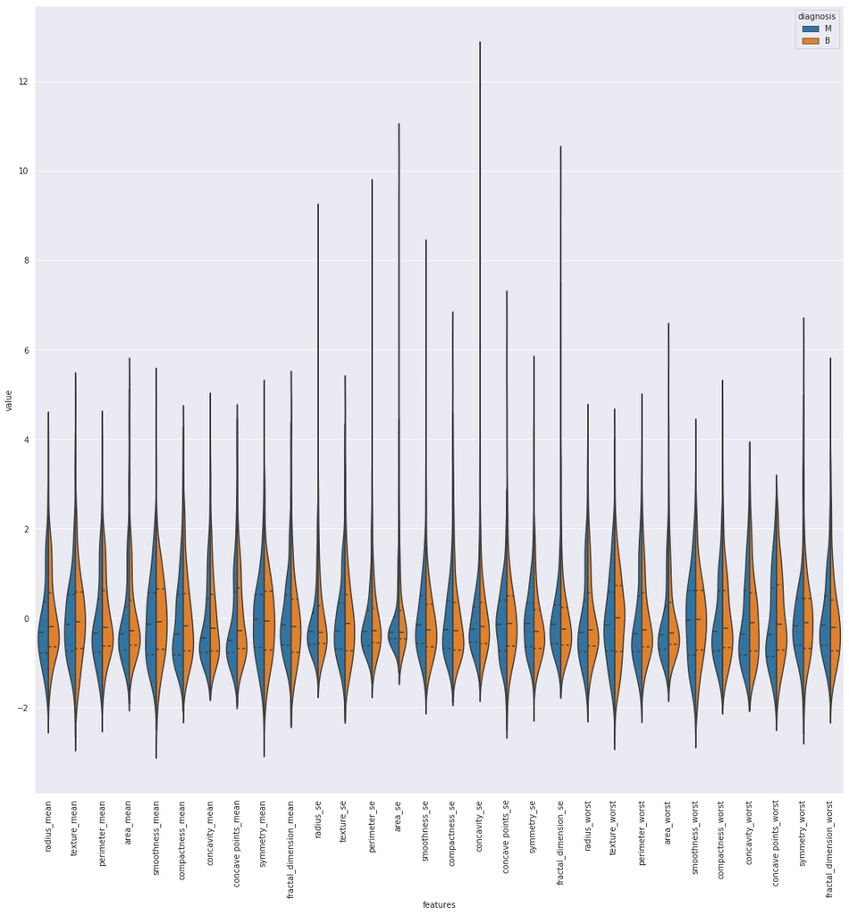

```python
figure=plt.figure(figsize=(18,18))
g1=sns.violinplot(x='features', y='value', hue='diagnosis', inner='quartile', data=X_train_vis, split=True)
g1.set_xticklabels(g1.get_xticklabels(), rotation=90);
```

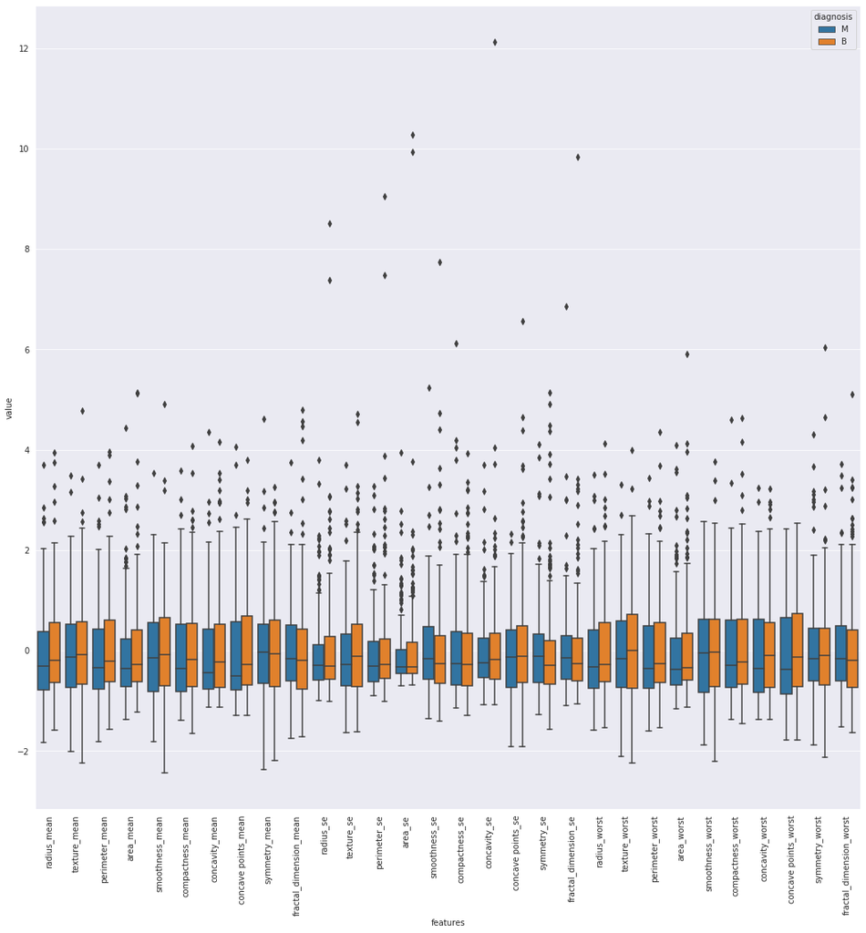

```python
figure=plt.figure(figsize=(18,18))
g1=sns.boxplot(x='features', y='value', hue='diagnosis',  data=X_train_vis)
g1.set_xticklabels(g1.get_xticklabels(), rotation=90);
```

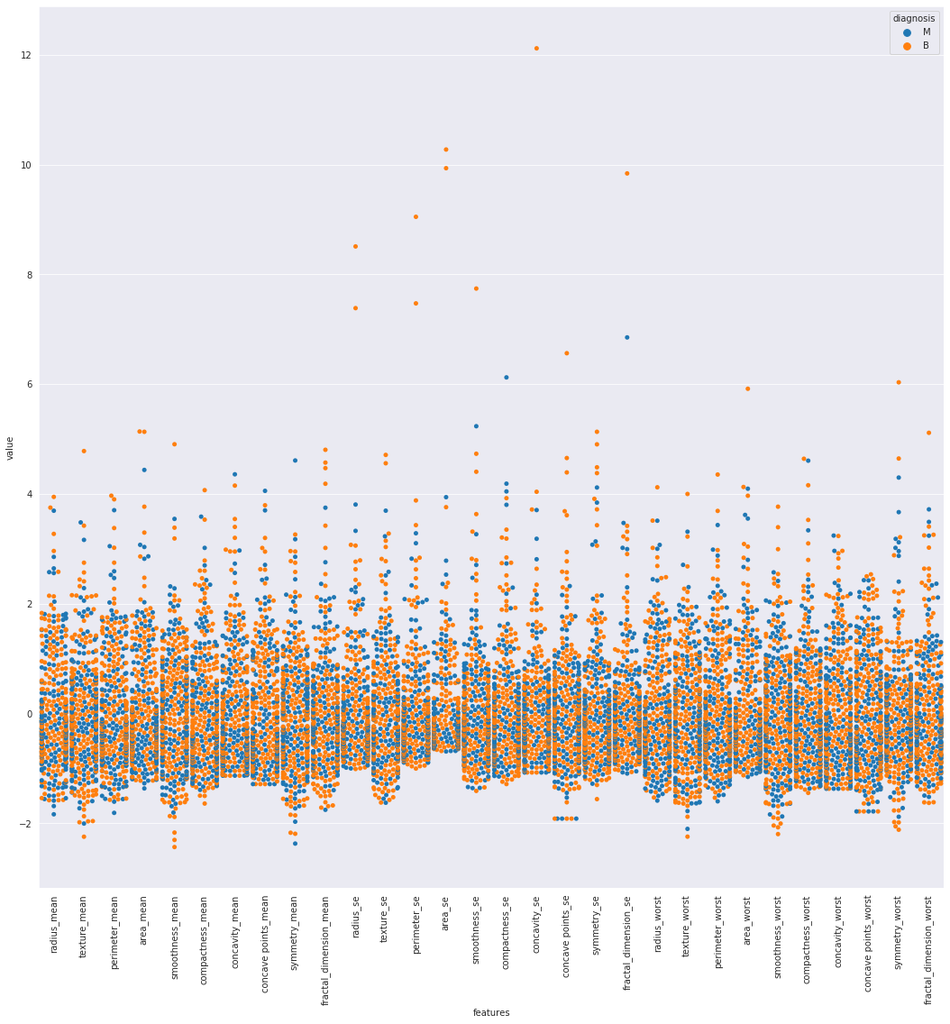

```python
figure=plt.figure(figsize=(18,18))
g1=sns.swarmplot(x='features', y='value', hue='diagnosis',  data=X_train_vis)
g1.set_xticklabels(g1.get_xticklabels(), rotation=90);
```

Por otro lado, como medida cuantitativa, vamos a obtener los indices de correlación entre las variables y mostrarlos en un mapa de calor.

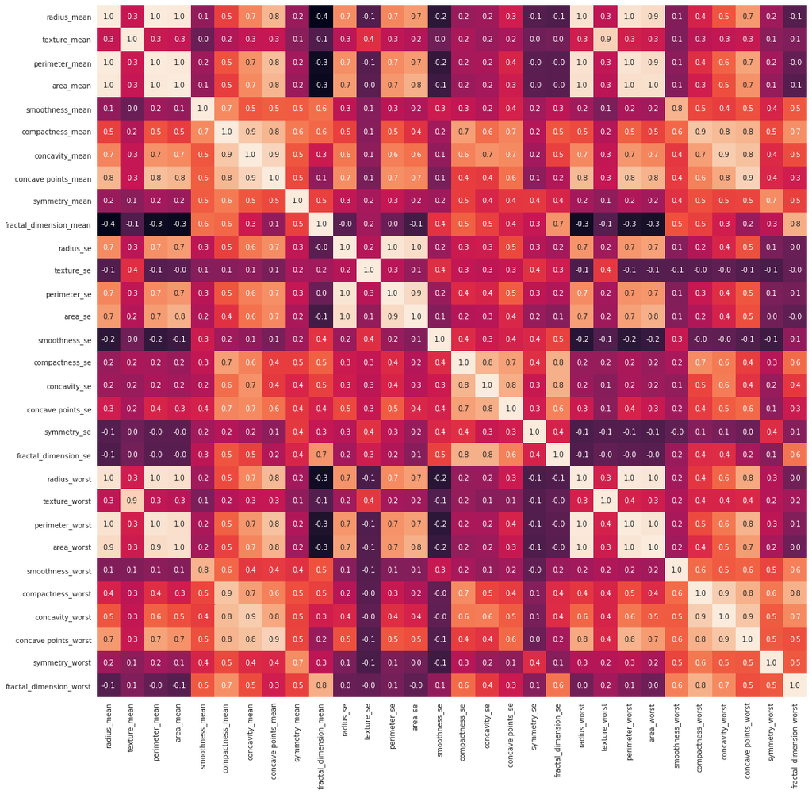

```python
figure=plt.figure(figsize=(18,18))
g1=sns.heatmap(X_train.corr(), annot=True, fmt='.1f', cbar=False)
```

Con la información que nos dan los grafos mostrados, podemos ver como claramente existen muchas variables que no aportan demasiado valor predictor debido a su excesiva correlación.

Vamos a evaluar cuales son las mejores variables predictoras según el método **SelectKBest**:

```python
from sklearn.feature_selection import SelectKBest, chi2, RFE, RFECV
from sklearn.ensemble import RandomForestClassifier
```

```python
select_feature = SelectKBest(chi2, k='all').fit(X_train, y_train)
```

```python
select_feature.scores_
```

```
array([1.77946492e+02, 6.06916433e+01, 1.34061092e+03, 3.66899557e+04,
       1.00015175e-01, 3.41839493e+00, 1.30547650e+01, 7.09766457e+00,
       1.95982847e-01, 3.42575072e-04, 2.45882967e+01, 4.07131026e-02,
       1.72696840e+02, 6.12741067e+03, 1.32470372e-03, 3.74071521e-01,
       6.92896719e-01, 2.01587194e-01, 1.39557806e-03, 2.65927071e-03,
       3.25782599e+02, 1.16958562e+02, 2.40512835e+03, 7.50217341e+04,
       2.63226314e-01, 1.19077581e+01, 2.58858117e+01, 8.90751003e+00,
       1.00635138e+00, 1.23087347e-01])
```

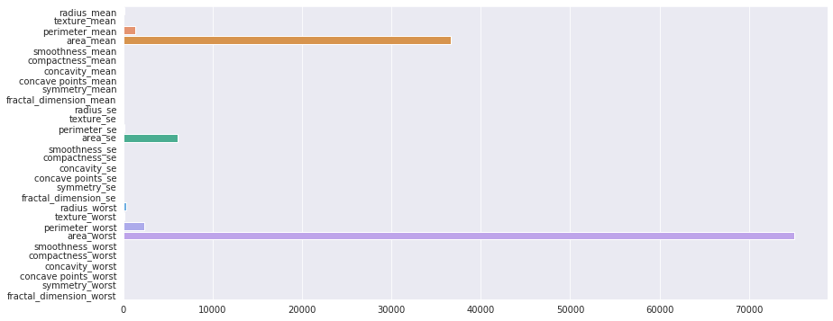

```python
figure_importances=pd.Series(data=select_feature.scores_, index=X_train.columns, name='f_imp')
figure=plt.figure(figsize=(14,6))
g1=sns.barplot(y=figure_importances.index, x=figure_importances.values, orient='h')
```

Haciendo uso del **conjunto** de grafos generados, vamos a desechar las siguientes columnas:

```python
list_col_drop=['radius_mean', 'perimeter_mean', 'radius_se', 'perimeter_se', 'compactness_mean', 'radius_worst', 'perimeter_worst', 'concavity_worst']
```

```python
X_train_reduced=X_train.drop(columns=list_col_drop)
```

De las variables que quedan, **no correladas**, vamos a ver cuales son las más importantes. Utilizaremos el algoritmo random forest. Para obtener los valores más fiables posibles vamos a realizar un sencillo *fine tuning* a través de una **RandomizedSearchCV**:

```python
rf_clf_fs = RandomForestClassifier(oob_score=True, bootstrap=True)
param_distributions={'n_estimators':[int(a) for a in np.linspace(start=20, stop=200, num=10)],
              'max_features':['sqrt', 'auto'],
              'max_depth':[int(a) for a in np.linspace(start=10, stop=100, num=10)],
              'min_samples_split':[a for a in np.arange(2,10)]}

random_searchcv=RandomizedSearchCV(rf_clf_fs, param_distributions=param_distributions, cv=5, n_iter=200, n_jobs=-1)
random_searchcv.fit(X_train_reduced, y_train)
```

```
RandomizedSearchCV(cv=5, error_score='raise-deprecating',
                   estimator=RandomForestClassifier(bootstrap=True,
                                                    class_weight=None,
                                                    criterion='gini',
                                                    max_depth=None,
                                                    max_features='auto',
                                                    max_leaf_nodes=None,
                                                    min_impurity_decrease=0.0,
                                                    min_impurity_split=None,
                                                    min_samples_leaf=1,
                                                    min_samples_split=2,
                                                    min_weight_fraction_leaf=0.0,
                                                    n_estimators='warn',
                                                    n_jobs=None, oob_sc...
                                                    verbose=0,
                                                    warm_start=False),
                   iid='warn', n_iter=200, n_jobs=-1,
                   param_distributions={'max_depth': [10, 20, 30, 40, 50, 60,
                                                      70, 80, 90, 100],
                                        'max_features': ['sqrt', 'auto'],
                                        'min_samples_split': [2, 3, 4, 5, 6, 7,
                                                              8, 9],
                                        'n_estimators': [20, 40, 60, 80, 100,
                                                         120, 140, 160, 180,
                                                         200]},
                   pre_dispatch='2*n_jobs', random_state=None, refit=True,
                   return_train_score=False, scoring=None, verbose=0)
```

```python
random_searchcv.best_score_, random_searchcv.best_params_
```

```
(0.964824120603015,
 {'n_estimators': 20,
  'min_samples_split': 3,
  'max_features': 'auto',
  'max_depth': 90})
```

```python
rf_feature_importances=RandomForestClassifier(**random_searchcv.best_params_)
rf_feature_importances.fit(X_train_reduced, y_train)
```

```
RandomForestClassifier(bootstrap=True, class_weight=None, criterion='gini',
                       max_depth=90, max_features='auto', max_leaf_nodes=None,
                       min_impurity_decrease=0.0, min_impurity_split=None,
                       min_samples_leaf=1, min_samples_split=3,
                       min_weight_fraction_leaf=0.0, n_estimators=20,
                       n_jobs=None, oob_score=False, random_state=None,
                       verbose=0, warm_start=False)
```

```python
feature_importances=pd.Series(rf_feature_importances.feature_importances_, index=X_train_reduced.columns, name='f_imp')
```

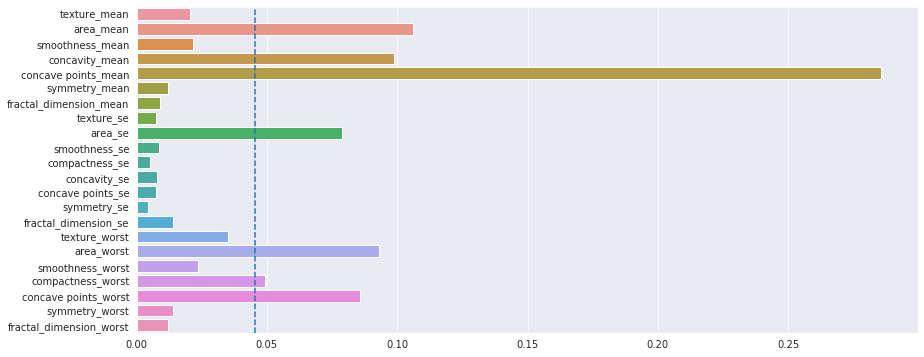

```python
figure=plt.figure(figsize=(14,6))
g1=sns.barplot(x=feature_importances.values, y=feature_importances.index, orient='h')
g1.axvline(np.mean(feature_importances.values), ls='--')
```

Parece ser que existen entre 7 y 8 características que destacan por encima del resto, para comprobar esto. Vamos a ver que nos dice la eliminación recursiva de variables utilizando este mismo clasificador.

```python
rfecv = RFECV(estimator=rf_feature_importances, step=1, cv=5,scoring='accuracy')   #5-fold cross-validation
rfecv = rfecv.fit(X_train_reduced, y_train)
```

```python
rfecv.n_features_
```

```
8
```

```python
X_train_reduced.columns[rfecv.support_]
```

```
Index(['area_mean', 'concavity_mean', 'concave points_mean', 'area_se',
       'texture_worst', 'area_worst', 'compactness_worst',
       'concave points_worst'],
      dtype='object')
```

Podemos quedarnos entonces con este subset de columnas como una de las opciones para entrenar nuestro modelo clasificador. Recordemos que este conjunto ha sido resultado de aplicar la técnica de selección de características.

Vamos a probar ahora con la técnica de extracción de características, con la cual se transforma el espacio original. Usaremos el análisis de componentes principales.

Una vez terminado el mismo, probaremos como rinde un *extra trees classifier* para los tres conjuntos de datos:

- El original estandarizado
- El obtenido mediante selección de características
- El obtenido mediante extracción de características

```python
from sklearn.decomposition import PCA
```

```python
pca=PCA(n_components=0.95)
```

```python
X_train_pca_transformed=pca.fit_transform(X_train_scaled_df)
```

```python
from sklearn.ensemble import ExtraTreesClassifier
```

```python
X_train_reduced=X_train.loc[:, X_train_reduced.columns[rfecv.support_]]
```

```python
scores_etc1=[]
scores_etc2=[]
scores_etc3=[]
for _ in range (0, 100):

    etc1=ExtraTreesClassifier(random_state=_, bootstrap=True, oob_score=True)
    etc2=ExtraTreesClassifier(random_state=_, bootstrap=True, oob_score=True)
    etc3=ExtraTreesClassifier(random_state=_, bootstrap=True, oob_score=True)

    etc1.fit(X_train_scaled_df, y_train)
    etc2.fit(X_train_reduced, y_train)
    etc3.fit(X_train_pca_transformed, y_train)

    scores_etc1.append(etc1.oob_score_)
    scores_etc2.append(etc2.oob_score_)
    scores_etc3.append(etc3.oob_score_)
```

[output not shown]

[output cut: 1697 more lines]

[output not shown]

Mostramos la media y desviación de los valores de precisión del clasificador para cada uno de los tres sets de entrenamiento:

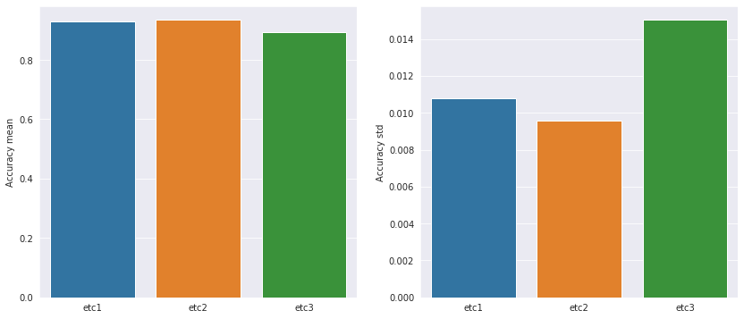

```python
figure, ax=plt.subplots(1,2,figsize=(14,6))
g1=sns.barplot(x=['etc1','etc2','etc3'], y=[np.mean(scores_etc1),np.mean(scores_etc2),np.mean(scores_etc3)], ax=ax[0])
g2=sns.barplot(x=['etc1','etc2','etc3'], y=[np.std(scores_etc1),np.std(scores_etc2),np.std(scores_etc3)], ax=ax[1])
g1.set_ylabel('Accuracy mean')
g2.set_ylabel('Accuracy std');
```

Parece ser que el mejor de los tres, es el entrenado sobre el set creado a partir de la técnica de selección de características.

Llegados a este punto, es hora de implementar diferentes algoritmos para hacer una comparativa entre ellos y hacer posteriormente un método ensamblado con el que daremos unos resultados finales.

```python
from sklearn.ensemble import AdaBoostClassifier
from sklearn.neighbors import KNeighborsClassifier
from sklearn.naive_bayes import GaussianNB
from sklearn.neural_network import MLPClassifier
from sklearn.tree import DecisionTreeClassifier
from scipy.stats import expon
```

Creamos estos 4 clasificadores y vamos haciendo *fine tuning* sobre cada uno de ellos:

```python
#dtc=DecisionTreeClassifier()
adaboost=AdaBoostClassifier(dtc)
kneighbors=KNeighborsClassifier()
nb=GaussianNB()
nn=MLPClassifier()
```

```python
param_distributions_adaboost={'algorithm':['SAMME', 'SAMME.R'],
                              'n_estimators':[int(a) for a in np.linspace(start=10, stop=200, num=20)],
                              'learning_rate': expon(scale=2),
                              'base_estimator__max_features':['sqrt', 'auto'],
                              'base_estimator__max_depth':[int(a) for a in np.linspace(start=10, stop=100, num=10)],
                              'base_estimator__min_samples_split':[a for a in np.arange(2,10)]}

param_distributions_kneighbors={'n_neighbors': [a for a in np.arange(2,10)], 'weights':['uniform', 'distance']}
param_distributions_nb={'var_smoothing':expon(scale=0.5)}
param_distributions_nn={'solver':['lbfgs','sgd','adam'], 'hidden_layer_sizes':([int(a) for a in np.linspace(start=10,stop=50,num=5)],), 'learning_rate_init':expon(scale=1), 'learning_rate':['constant', 'invscaling', 'adaptive'] }
```

```python
rsch_adaboost=RandomizedSearchCV(adaboost, param_distributions=param_distributions_adaboost, n_jobs=-1, cv=5, n_iter=200, scoring='accuracy',refit=True)
rsch_kneighbors=RandomizedSearchCV(kneighbors, param_distributions=param_distributions_kneighbors, n_jobs=-1, cv=5, n_iter=200,scoring='accuracy',refit=True)
rsch_nb=RandomizedSearchCV(nb, param_distributions=param_distributions_nb, n_jobs=-1, cv=5, n_iter=200,scoring='accuracy',refit=True)
rsch_nn=RandomizedSearchCV(nn, param_distributions=param_distributions_nn, n_jobs=-1, cv=5, n_iter=200,scoring='accuracy', refit=True)
```

```python
rsch_nb.fit(X_train_reduced, y_train)
```

```
RandomizedSearchCV(cv=5, error_score='raise-deprecating',
                   estimator=GaussianNB(priors=None, var_smoothing=1e-09),
                   iid='warn', n_iter=200, n_jobs=-1,
                   param_distributions={'var_smoothing': <scipy.stats._distn_infrastructure.rv_frozen object at 0x7f32571a5278>},
                   pre_dispatch='2*n_jobs', random_state=None, refit=True,
                   return_train_score=False, scoring='accuracy', verbose=0)
```

```python
rsch_adaboost.fit(X_train_reduced, y_train)
```

```
RandomizedSearchCV(cv=5, error_score='raise-deprecating',
                   estimator=AdaBoostClassifier(algorithm='SAMME.R',
                                                base_estimator=DecisionTreeClassifier(class_weight=None,
                                                                                      criterion='gini',
                                                                                      max_depth=None,
                                                                                      max_features=None,
                                                                                      max_leaf_nodes=None,
                                                                                      min_impurity_decrease=0.0,
                                                                                      min_impurity_split=None,
                                                                                      min_samples_leaf=1,
                                                                                      min_samples_split=2,
                                                                                      min_weight_fraction_leaf=0.0,
                                                                                      p...
                                        'base_estimator__max_features': ['sqrt',
                                                                         'auto'],
                                        'base_estimator__min_samples_split': [2,
                                                                              3,
                                                                              4,
                                                                              5,
                                                                              6,
                                                                              7,
                                                                              8,
                                                                              9],
                                        'learning_rate': <scipy.stats._distn_infrastructure.rv_frozen object at 0x7f32571a5898>,
                                        'n_estimators': [10, 20, 30, 40, 50, 60,
                                                         70, 80, 90, 100, 110,
                                                         120, 130, 140, 150,
                                                         160, 170, 180, 190,
                                                         200]},
                   pre_dispatch='2*n_jobs', random_state=None, refit=True,
                   return_train_score=False, scoring='accuracy', verbose=0)
```

```python
rsch_kneighbors.fit(X_train_reduced, y_train)
```

```
RandomizedSearchCV(cv=5, error_score='raise-deprecating',
                   estimator=KNeighborsClassifier(algorithm='auto',
                                                  leaf_size=30,
                                                  metric='minkowski',
                                                  metric_params=None,
                                                  n_jobs=None, n_neighbors=5,
                                                  p=2, weights='uniform'),
                   iid='warn', n_iter=200, n_jobs=-1,
                   param_distributions={'n_neighbors': [2, 3, 4, 5, 6, 7, 8, 9],
                                        'weights': ['uniform', 'distance']},
                   pre_dispatch='2*n_jobs', random_state=None, refit=True,
                   return_train_score=False, scoring='accuracy', verbose=0)
```

```python
rsch_nn.fit(X_train_reduced, y_train)
```

```
RandomizedSearchCV(cv=5, error_score='raise-deprecating',
                   estimator=MLPClassifier(activation='relu', alpha=0.0001,
                                           batch_size='auto', beta_1=0.9,
                                           beta_2=0.999, early_stopping=False,
                                           epsilon=1e-08,
                                           hidden_layer_sizes=(100,),
                                           learning_rate='constant',
                                           learning_rate_init=0.001,
                                           max_iter=200, momentum=0.9,
                                           n_iter_no_change=10,
                                           nesterovs_momentum=True, power_t=0.5,
                                           rand...
                   iid='warn', n_iter=200, n_jobs=-1,
                   param_distributions={'hidden_layer_sizes': ([10, 20, 30, 40,
                                                                50],),
                                        'learning_rate': ['constant',
                                                          'invscaling',
                                                          'adaptive'],
                                        'learning_rate_init': <scipy.stats._distn_infrastructure.rv_frozen object at 0x7f32571a5e48>,
                                        'solver': ['lbfgs', 'sgd', 'adam']},
                   pre_dispatch='2*n_jobs', random_state=None, refit=True,
                   return_train_score=False, scoring='accuracy', verbose=0)
```

Veamos cuales son los mejores resultados de cada uno de ellos:

```python
rsch_adaboost.best_score_,rsch_kneighbors.best_score_,rsch_nb.best_score_,rsch_nn.best_score_
```

```
(0.9698492462311558, 0.914572864321608, 0.8894472361809045, 0.9221105527638191)
```

Vamos a implementar ahora los dos tipos de clasificadores por votación:

```
1.- Soft Voting: usa las probabilidades de prediccion de los estimadores (generalmente funciona mejor).
2.- Hard Voting: usa la predicción más votada (*most frequent*).
```

```python
from sklearn.ensemble import VotingClassifier
```

```python
voting_classifier=VotingClassifier(voting='soft', estimators=[
    ('rf', rf_feature_importances),
    ('ada', rsch_adaboost.best_estimator_),
    ('kneighbors', rsch_kneighbors.best_estimator_),
    ('bn', rsch_nb.best_estimator_),
    ('nn', rsch_nn.best_estimator_)
])
```

```python
from sklearn.model_selection import cross_val_score
```

```python
voting_score=cross_val_score(voting_classifier, X_train_reduced, y_train, scoring='accuracy', cv=5, n_jobs=-1)
```

```python
voting_score_mean=np.mean(voting_score)
voting_score_std=np.std(voting_score)
```

```python
voting_score_mean, voting_score_std
```

```
(0.9270512820512821, 0.02695861512859191)
```

```python
voting_classifier_hard=VotingClassifier(voting='hard', estimators=[
    ('rf', rf_feature_importances),
    ('ada', rsch_adaboost.best_estimator_),
    ('kneighbors', rsch_kneighbors.best_estimator_),
    ('bn', rsch_nb.best_estimator_),
    ('nn', rsch_nn.best_estimator_)
])
```

```python
voting_score=cross_val_score(voting_classifier_hard, X_train_reduced, y_train, scoring='accuracy', cv=5, n_jobs=-1)
```

```python
voting_hard_score_mean=np.mean(voting_score)
voting_hard_score_std=np.std(voting_score)
```

```python
voting_hard_score_mean, voting_hard_score_std
```

```
(0.9497435897435897, 0.028508998314187923)
```

En este caso, el clasificador de tipo *hard voting* ha logrado mejores resultados. No obstante, se esperaban mejores... ¡Vamos a probar con un método ensamblado de tipo *stacking*.

Para ello primero tenemos que generar nuestro set de entrenamiento, que consiste en las predicciones del set de entrenamiento de sus respectivos estimadores.

Como algoritmo ensamblador usaremos de nuevo un *extra trees classifier*

```python
#creating the array to store the estimators predictions
X_train_stacking=np.chararray((len(X_train_reduced), 4),)
```

```python
for _ in range(0,len(X_train_reduced)):
    X_train_stacking[_,0]=rsch_adaboost.best_estimator_.predict(X_train_reduced.iloc[_,:].values.reshape(1,8))[0]
    X_train_stacking[_,1]=rsch_kneighbors.best_estimator_.predict(X_train_reduced.iloc[_,:].values.reshape(1,8))[0]
    X_train_stacking[_,2]= rsch_nb.best_estimator_.predict(X_train_reduced.iloc[_,:].values.reshape(1,8))[0]
    X_train_stacking[_,3]=rsch_nn.best_estimator_.predict(X_train_reduced.iloc[_,:].values.reshape(1,8))[0]
```

```python
#we will use an extra trees classifier
extra_trees_stacking=ExtraTreesClassifier(bootstrap=True, oob_score=True)
```

```python
X_train_stacking_float=np.empty(X_train_stacking.shape,)
```

```python
for col in range(0,4):
    for row in range(0, X_train_stacking.shape[0]):
        if X_train_stacking[row, col]==b'B':
            X_train_stacking_float[row, col]=0
        else:
            X_train_stacking_float[row, col]=1
```

```python
param_distributions_stacking={'n_estimators': np.arange(1,10),
                             'max_depth':[2,3,4,5,6,7,8,9,10,20,30,40],
                              'min_samples_split':[2,3,4,5,6],
                              'max_features':['sqrt', 'auto'],
                              }
```

```python
randomized_searchcv_stacking=RandomizedSearchCV(extra_trees_stacking, param_distributions=param_distributions_stacking, n_jobs=-1, cv=5, n_iter=200, scoring='accuracy', refit=True)
```

```python
randomized_searchcv_stacking.fit(X_train_stacking_float, y_train)
```

```
RandomizedSearchCV(cv=5, error_score='raise-deprecating',
                   estimator=ExtraTreesClassifier(bootstrap=True,
                                                  class_weight=None,
                                                  criterion='gini',
                                                  max_depth=None,
                                                  max_features='auto',
                                                  max_leaf_nodes=None,
                                                  min_impurity_decrease=0.0,
                                                  min_impurity_split=None,
                                                  min_samples_leaf=1,
                                                  min_samples_split=2,
                                                  min_weight_fraction_leaf=0.0,
                                                  n_estimators='warn',
                                                  n_jobs=None, oob_scor...
                                                  random_state=None, verbose=0,
                                                  warm_start=False),
                   iid='warn', n_iter=200, n_jobs=-1,
                   param_distributions={'max_depth': [2, 3, 4, 5, 6, 7, 8, 9,
                                                      10, 20, 30, 40],
                                        'max_features': ['sqrt', 'auto'],
                                        'min_samples_split': [2, 3, 4, 5, 6],
                                        'n_estimators': array([1, 2, 3, 4, 5, 6, 7, 8, 9])},
                   pre_dispatch='2*n_jobs', random_state=None, refit=True,
                   return_train_score=False, scoring='accuracy', verbose=0)
```

```python
randomized_searchcv_stacking.best_score_
```

```
1.0
```

```python
randomized_searchcv_stacking.best_estimator_
```

```
ExtraTreesClassifier(bootstrap=True, class_weight=None, criterion='gini',
                     max_depth=2, max_features='sqrt', max_leaf_nodes=None,
                     min_impurity_decrease=0.0, min_impurity_split=None,
                     min_samples_leaf=1, min_samples_split=6,
                     min_weight_fraction_leaf=0.0, n_estimators=6, n_jobs=None,
                     oob_score=True, random_state=None, verbose=0,
                     warm_start=False)
```

```python
stacking_score_rf=cross_val_score(extra_trees_stacking, X_train_stacking_float, y_train, cv=5, n_jobs=-1, scoring='accuracy')
```

```python
stacking_score_rf
```

```
array([1., 1., 1., 1., 1.])
```

Mostramos en forma de grafo cuales son los mejores valores de precisión de cada uno de los métodos clasificadores vistos hasta el momento.

Vemos como el mejor parece ser el de tipo *stacking*, el cual usaremos para hacer las predicciones sobre el set de testeo, y ver el valor de precisión como métrica de la bondad del mismo

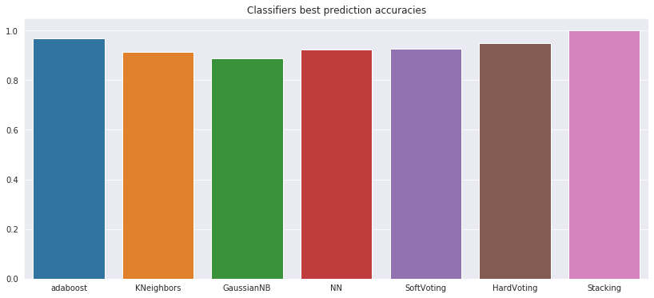

```python
figure=plt.figure(figsize=(14,6))
g1=sns.barplot(x=['adaboost', 'KNeighbors', 'GaussianNB', 'NN', 'SoftVoting', 'HardVoting', 'Stacking'], y=[rsch_adaboost.best_score_,rsch_kneighbors.best_score_,rsch_nb.best_score_,rsch_nn.best_score_,voting_score_mean,voting_hard_score_mean, randomized_searchcv_stacking.best_score_])
g1.set_title('Classifiers best prediction accuracies');
```

```python
X_test_reduced=X_test.loc[:, X_train_reduced.columns]
```

```python
X_test_reduced.shape
```

```
(171, 8)
```

```python
X_test_stacking=np.chararray((len(X_test_reduced), 4),)

for _ in range(0,len(X_test_reduced)):
    X_test_stacking[_,0]=rsch_adaboost.best_estimator_.predict(X_test_reduced.iloc[_,:].values.reshape(1,8))[0]
    X_test_stacking[_,1]=rsch_kneighbors.best_estimator_.predict(X_test_reduced.iloc[_,:].values.reshape(1,8))[0]
    X_test_stacking[_,2]= rsch_nb.best_estimator_.predict(X_test_reduced.iloc[_,:].values.reshape(1,8))[0]
    X_test_stacking[_,3]=rsch_nn.best_estimator_.predict(X_test_reduced.iloc[_,:].values.reshape(1,8))[0]

X_test_stacking_float=np.empty(X_test_stacking.shape,)

for col in range(0,4):
    for row in range(0, X_test_stacking.shape[0]):
        if X_test_stacking[row, col]==b'B':
            X_test_stacking_float[row, col]=0
        else:
            X_test_stacking_float[row, col]=1
```

```python
stacking_predictions=randomized_searchcv_stacking.best_estimator_.predict(X_test_stacking_float)
```

```python
from sklearn.metrics import accuracy_score
```

```python
stacking_accuracy=accuracy_score(y_test, stacking_predictions)
```

Finalmente mostramos la metrica de la precisión. ¡Un resultado bastante bueno!

```python
print('The accuracy score we have finally achivied: {:.4f}'.format(stacking_accuracy))
```

```
The accuracy score we have finally achivied: 0.9825
```